# The Numpy Library

### by Hunter LaValley

```python
import numpy as np
import matplotlib.pylab as plt
from numpy import random
import numpy_financial as npf
import pandas as pd
```

[output not shown]

```python
l1 = [1, 2, 3, 4, 5] #ordinary list
l2 = [[1,2,3], [4,5,6], [7,8,9]] #multidimensional list
l3 = np.array(l2) #Using numpy to take a list and define an array
l4 = np.array([1, 2, 3]) #Creating 1-D array with defined values
l5 = np.array([[1,2,3], [4,5,6], [7,8,9]]) #Creating a multidimensional array with defined values
np.arange(1, 10,2) #arange makes an array of the form: (start, stop, step) where stop is not included.
np.linspace(1,10,2) #linspace makes an array of the form: (start, stop, # of values)
np.zeros(4) #1-D array of 4 zero's
np.zeros((2, 3)) #2x3 array of zero's, follows RC-Cola rule
np.ones((2, 3)) #2x3 array of one's
l5.size #number of items in the array
l5.dtype #returns type of array:
randomarray1D = np.random.randint(0, 100, 10) # 1-D array with 10 random values from 0 to 100
random2x3array = np.random.randint(0, 100, size=(2, 3)) # 2x3 matrix with 6 random values from 0 to 100
# np.random.randint? #Get help with a function by placing a ? at the end of its name

print("Ordinary list: ", l1)
print("Multidimensional list: ", l2)
print("Array made from list: ", l3)
print("1-D array: ", l4)
print("Multidimensional array: ", l5)
print("Array made from arange(): ", np.arange(1, 10,2))
print("Array made from linspace(): ", np.linspace(1,10,2))
print("Array of zeros made from zeros(): ", np.zeros(4))
print("2x3 array made from zeros(): ", np.zeros((2, 3)))
print("2x3 array made from ones(): ", np.ones((2, 3)))
print("Size of l5: ", l5.size)
print("l5 is array type: ", l5.dtype)
print("1-D array of 10 random values: ", randomarray1D)
print("2x3 array of random values: ", random2x3array )
```

```
Ordinary list:  [1, 2, 3, 4, 5]
Multidimensional list:  [[1, 2, 3], [4, 5, 6], [7, 8, 9]]
Array made from list:  [[1 2 3]
 [4 5 6]
 [7 8 9]]
1-D array:  [1 2 3]
Multidimensional array:  [[1 2 3]
 [4 5 6]
 [7 8 9]]
Array made from arange():  [1 3 5 7 9]
Array made from linspace():  [ 1. 10.]
Array of zeros made from zeros():  [0. 0. 0. 0.]
2x3 array made from zeros():  [[0. 0. 0.]
 [0. 0. 0.]]
2x3 array made from ones():  [[1. 1. 1.]
 [1. 1. 1.]]
Size of l5:  9
l5 is array type:  int32
1-D array of 10 random values:  [15 58 67 20 66 72  0 37 32 25]
2x3 array of random values:  [[70 82 21]
 [62 32 48]]
```

# Slicing and Replacing

```python
#Recall from before
l1 = [1, 2, 3, 4, 5]
l2 = np.array([[1,2,3], [4,5,6], [7,8,9]])

'''Replacing Indices'''
l1[0] = 999 #changing a value at the index 0 in 1-D
l2.itemset(4,777) #changing the 4th value in l5 to 777
l2.itemset((2,2), 969) #changing the value at (2,2) to 999
l2.shape #shape of array
l2[0,1] #value at an index
l2.item(0,1) #value at an index
l3 = np.take(l2, [0, 3, 6]) #values at specific indices 3, 6, and 9
print("Result from changing the value of l[0] to 999: ", l1)
print("l2 after item setting: ", l2)
print("Shape of l2: ", l2.shape)
print("Value at index l2[0,1]: ", l2[0,1])
print("Value at index l2.item(0,1): ", l2.item(0,1)) #value at an index
print("Values at specific indicies 0, 3, 6: ", l3) #values at specific indices 3, 6, and 9

np.put(l2, [0, 3, 6], [10, 10, 10]) #changing values at indices 3, 6 and 9 to 10 using polymorphism
print("l2 after changing specific indicies simlutaneously:", l2)

'''Slicing'''
# Start at 1st through 5th with 2 step
l2[:9:2] #start at 0, stop at 9, step in 2's
l2[:,0] #Return the first value (index of 1) in each row
l2[:,1] #Return the second value (index of 1) in each row
l2[:,2] #Return the third value (index of 1) in each row
l2[::-1]# Flip the array by reversing the indices
print("Starting at 0, stoping at 9, stepping in 2's: ", l2[:9:2])
print("Returning the first value (index of 1) in each row: ", l2[:,0])
print("Returning the second value (index of 1) in each row: ", l2[:,1])
print("Returning the third value (index of 1) in each row: ", l2[:,2])
print("Flipping the array by reversing the indices: ", l2[::-1])

'''Get the evens by defining a matrix such that it has all the values
of l5 if and only if their modulus with 2 is 0'''
evens = l5[l5%2==0]
print("Evens: ", evens)

l2[l2 > 5] #Returns all values from l5 greater than 5, can use all comparison operators
l2[(l2 > 5) & (l2 < 9)] #Returns all values in l5 such that 5 < x < 9
l2[(l2 > 5) | (l2 == 10)] #Returns all values that are either greater than 5 or equal to 10

print("All values greater than 5 in l2: ", l2[l2 > 5] )
print("All values in l2 such that 5 < x < 9: ", l2[(l2 > 5) & (l2 < 9)] )
print("All values in l2 that are either greater than 5 or equal to 10: ", l2[(l2 > 5) | (l2 == 10)] )
print("Unique values in l2: ", np.unique(l2))

'''Reshaping'''
l5 = np.array([[12,21,3], [43,52,6], [17,18,91]])
print("original l5: ", l5)
l5.reshape((9,1))# Reshape array l5 from 3x3 to 1x9
print("l5 reshaped: ", l5.reshape((9,1)))

''' If you reshape to drastically, then either items are lost or zeros are added to fill the size'''
a = np.array([[0,1],[2,3]])
print("Original a: ", a)
print("Resized a: ", np.resize(a,(2,3)))


l5.transpose() #Transposes l5 in the fashion of linear algebra
l5.swapaxes(0,1) #Swaps the axes like a transposition
l5.flatten() # Collapses a multidimensional array into a 1-D array
l5.flatten('F') # Flattens but in column order


print("The transpose: ", l5.transpose())
print("Swapping axes = transposing: ", l5.swapaxes(0,1))
print("Flattening to 1-D: ", l5.flatten())
print("Flattening in column order: ", l5.flatten('F'))

'''These work within the conext of either a row or a column, so if your array is too simple
then you won't see what it does'''

l5.sort(axis=1) #arranges row values to be in ascending order
print("Arranged row values in ascending order: ", l5)

l5.sort(axis=0) #arranges column values to be in ascending order
print("Arranged column values in ascending order: ", l5)
```

```
Result from changing the value of l[0] to 999:  [999, 2, 3, 4, 5]
l2 after item setting:  [[  1   2   3]
 [  4 777   6]
 [  7   8 969]]
Shape of l2:  (3, 3)
Value at index l2[0,1]:  2
Value at index l2.item(0,1):  2
Values at specific indicies 0, 3, 6:  [1 4 7]
l2 after changing specific indicies simlutaneously: [[ 10   2   3]
 [ 10 777   6]
 [ 10   8 969]]
Starting at 0, stoping at 9, stepping in 2's:  [[ 10   2   3]
 [ 10   8 969]]
Returning the first value (index of 1) in each row:  [10 10 10]
Returning the second value (index of 1) in each row:  [  2 777   8]
Returning the third value (index of 1) in each row:  [  3   6 969]
Flipping the array by reversing the indices:  [[ 10   8 969]
 [ 10 777   6]
 [ 10   2   3]]
Evens:  [2 4 6 8]
All values greater than 5 in l2:  [ 10  10 777   6  10   8 969]
All values in l2 such that 5 < x < 9:  [6 8]
All values in l2 that are either greater than 5 or equal to 10:  [ 10  10 777   6  10   8 969]
Unique values in l2:  [  2   3   6   8  10 777 969]
original l5:  [[12 21  3]
 [43 52  6]
 [17 18 91]]
l5 reshaped:  [[12]
 [21]
 [ 3]
 [43]
 [52]
 [ 6]
 [17]
 [18]
 [91]]
Original a:  [[0 1]
 [2 3]]
Resized a:  [[0 1 2]
 [3 0 1]]
The transpose:  [[12 43 17]
 [21 52 18]
 [ 3  6 91]]
Swapping axes = transposing:  [[12 43 17]
 [21 52 18]
 [ 3  6 91]]
Flattening to 1-D:  [12 21  3 43 52  6 17 18 91]
Flattening in column order:  [12 43 17 21 52 18  3  6 91]
Arranged row values in ascending order:  [[ 3 12 21]
 [ 6 43 52]
 [17 18 91]]
Arranged column values in ascending order:  [[ 3 12 21]
 [ 6 18 52]
 [17 43 91]]
```

# Stacking, Splitting, and Copying

```python
a1 = np.random.randint(10, size=(3, 3)) #Recall how to make a random number array
print("a1: \n", a1)
a2 = np.random.randint(10, size=(3, 3)) #Recall how to make a random number array
print("a2: \n", a2)

a3 = np.vstack((a1, a2)) # Stacking a2 under a1 vertically
a4 = np.hstack((a1, a2)) # Stacking a1 against a2 horizontally
print("Vertical stack: ", np.vstack((a1, a2)))
print("Horizontal stack: ", np.hstack((a1, a2)))

print("a3: \n", a3)
print("a4: \n", a4)
a3 = np.column_stack((a1, a2)) #Combining two arrays column-wise
a4 = np.row_stack((a1, a2)) #Combining two arrays row-wise
print("Column stack: ", np.column_stack((a1, a2)))
print("Row stack: ", np.row_stack((a1, a2)))


a5 = np.random.randint(10, size=(3, 2)) #New random array
print("a5: \n", a5)

'''Splits must be result in an equal division'''
print(np.hsplit(a5, 2)) # Splitting a5 into 5 new arrays
np.hsplit(a5, (1, 3)) # Splitting after 1nd & 3rd column

'''Copying arrays'''

copy1 = np.random.randint(10, size=(3, 3))
copy2 = copy1 #Both name variables point at the same array

copy1[0,0] = 999
print("copy1: \n", copy1)
print("copy2: \n", copy2)

''' Creating a "view" of data where
the changes you making indexing and replacing values
don't affect original'''

copy3 = copy1.view()
print("copy3: \n", copy3)
copy3 = copy3.flatten('F')
print("copy3: \n", copy3)
print("copy1: \n", copy1)
copy4 = copy1.copy() #Copying and creating the new array

'''Deleting rows and columns.
I commented these out because you have to do one at a time or else go out of bounds,
or keep redefining a1 over and over again. '''
a1 = np.array([[1,2,3], [4,5,6], [7,8,9]])
#a2= np.delete(a1,0 , 0) #deletes 1st row
#a2= np.delete(a1, 0 , 1 ) #deletes 1st column
#a2= np.delete(a1, 1 , 0 ) #deletes 2nd row
#a2= np.delete(a1, 1 , 1 ) #deletes 2nd column
#a2= np.delete(a1, 2, 0 ) #deletes 3rd row
#a2= np.delete(a1, 2 , 1 ) #deletes 3rd column
#print(a2)
```

```
a1:
 [[6 0 6]
 [9 6 4]
 [7 3 9]]
a2:
 [[5 0 1]
 [6 7 9]
 [2 2 1]]
Vertical stack:  [[6 0 6]
 [9 6 4]
 [7 3 9]
 [5 0 1]
 [6 7 9]
 [2 2 1]]
Horizontal stack:  [[6 0 6 5 0 1]
 [9 6 4 6 7 9]
 [7 3 9 2 2 1]]
a3:
 [[6 0 6]
 [9 6 4]
 [7 3 9]
 [5 0 1]
 [6 7 9]
 [2 2 1]]
a4:
 [[6 0 6 5 0 1]
 [9 6 4 6 7 9]
 [7 3 9 2 2 1]]
Column stack:  [[6 0 6 5 0 1]
 [9 6 4 6 7 9]
 [7 3 9 2 2 1]]
Row stack:  [[6 0 6]
 [9 6 4]
 [7 3 9]
 [5 0 1]
 [6 7 9]
 [2 2 1]]
a5:
 [[3 5]
 [4 2]
```

[output cut: 9 more lines]

```
 [  8   7   1]]
copy2:
 [[999   2   3]
 [  6   5   9]
 [  8   7   1]]
copy3:
 [[999   2   3]
 [  6   5   9]
 [  8   7   1]]
copy3:
 [999   6   8   2   5   7   3   9   1]
copy1:
 [[999   2   3]
 [  6   5   9]
 [  8   7   1]]
```

# Numpy Arithmetic

```python
print("Ceiling function: " , np.ceil([1.2, 2.5, 3.9, 4.4, 3.3, 8.1])) # Rounds up every entry
print("Floor function: " , np.floor([1.2, 2.5, 3.9, 4.4, 3.3, 8.1])) # Rounds down every entry

#Defining two arrays to play around with
a1 = np.array([1, 2, 3, 4])
a2 = np.array([2, 4, 6, 8])
np.add(a1, 999)# Add individual numbers to array

a1 + a2# Addition
a1 - a2# Subtraction
a1 * a2# Multiplication
a1 / a2# Division
np.add(a1, a2) # Addition
np.subtract(a1, a2)# Subtraction
np.multiply(a1, a2)# Multiplication
np.divide(a1, a2)# Division
'''These do the same thing, observe:'''
print("a1 + a2: ", a1 + a2)
print("np.add(a1, a2): " , np.add(a1, a2))
print("a1 - a2: ", a1 - a2)
print("np.subtract(a1, a2): " , np.subtract(a1, a2))
print("a1 * a2: ", a1 * a2)
print("np.multiply(a1, a2): " , np.multiply(a1, a2))
print("a1 / a2: ", a1 / a2)
print("np.divide(a1, a2): " , np.divide(a1, a2))

### More Math ###
a5 = np.array([[2, 4], [6, 8]])
a6 = np.array([[1, 2], [3, 4]])
print("a5: \n", a5)
print("a6: \n", a6)

np.remainder(a6, a5)# Divides elements in 1st array by 2nd array and returns remainder
np.power(a6, a5)# Return values in 1st array to powers defined in 2nd array
np.sqrt(a1)# Square root
np.cbrt(a1)# Cube root
np.absolute([-1, -2])# Absolute value of every element
np.exp(a1)# Exponential of all elements in array
print("Divides elements in 1st array by 2nd array and returns remainder", np.remainder(a6, a5))
print("Return values in 1st array to powers defined in 2nd array", np.power(a6, a5))
print("Square root", np.sqrt(a1))
print("Cube root", np.cbrt(a1))
print("Absolute value of every element", np.absolute([-1, -2]))
print("Exponential of all elements in array", np.exp(a1))

''':::Log functions:::'''
np.log(a1) #log base e
np.log2(a1) #log base 2
np.log10(a1) #log base 10
np.gcd.reduce([9, 12, 15])# Greatest common divisor
np.lcm.reduce([9, 12, 15])# Lowest common multiple
print("log base e: ", np.log(a1))
print("log base 2: ",np.log2(a1))
print("log base 10: ",np.log10(a1))
print("Greatest common divisor: ",np.gcd.reduce([9, 12, 15]))
print("Lowest common multiple: ",np.lcm.reduce([9, 12, 15]))


''':::Random values:::'''
a3 = random.randint(100, size=(4))# Random 4 digit 1-D array between 0 to 100
print("a3 = ", a3)
a4 = random.randint(100, size=(3, 3))# Random 2 by 3 digit 2D array between 0 to 100
print("a4 = ", a4)
print("4 random floats: ", random.rand(4)) # Get 4 random floats
print("Random choice: ", random.choice(a1)) # Get a random value from an array
# Get index for max value per column
index_of_max = a4.argmax(axis=0)

''':::Index Arithmetic:::'''

print("Max value per column in a4: ", index_of_max)

max_nums = a4[index_of_max] # Get numbers corresponding to indexes
a4[index_of_max, range(a4.shape[1])]

squared_entries = np.arange(6)**2# Can receive 6 values and square them
print("squared_entries: ", squared_entries[a1])

a4.sum()# Sum all the values in array
a4.sum(axis=0)# Summing the columns
a4.cumsum(axis=1)# Sum of each row
a4.min(axis=1)# Min of each row
a4.max(axis=0)# Max of each column

print("Sum all the values in array", a4.sum())
print("Summing the columns", a4.sum(axis=0))
print("Sum of each row ", a4.cumsum(axis=1))
print("Min of each row", a4.min(axis=1))
print("Max of each column ", a4.max(axis=0))
```

```
Ceiling function:  [2. 3. 4. 5. 4. 9.]
Floor function:  [1. 2. 3. 4. 3. 8.]
a1 + a2:  [ 3  6  9 12]
np.add(a1, a2):  [ 3  6  9 12]
a1 - a2:  [-1 -2 -3 -4]
np.subtract(a1, a2):  [-1 -2 -3 -4]
a1 * a2:  [ 2  8 18 32]
np.multiply(a1, a2):  [ 2  8 18 32]
a1 / a2:  [0.5 0.5 0.5 0.5]
np.divide(a1, a2):  [0.5 0.5 0.5 0.5]
a5:
 [[2 4]
 [6 8]]
a6:
 [[1 2]
 [3 4]]
Divides elements in 1st array by 2nd array and returns remainder [[1 2]
 [3 4]]
Return values in 1st array to powers defined in 2nd array [[    1    16]
 [  729 65536]]
Square root [1.         1.41421356 1.73205081 2.        ]
Cube root [1.         1.25992105 1.44224957 1.58740105]
Absolute value of every element [1 2]
Exponential of all elements in array [ 2.71828183  7.3890561  20.08553692 54.59815003]
log base e:  [0.         0.69314718 1.09861229 1.38629436]
log base 2:  [0.        1.        1.5849625 2.       ]
log base 10:  [0.         0.30103    0.47712125 0.60205999]
Greatest common divisor:  3
Lowest common multiple:  180
a3 =  [20 52 44  5]
a4 =  [[14 34 12]
 [57 27 35]
 [34 35 21]]
4 random floats:  [0.89068982 0.26617372 0.69530703 0.161248  ]
Random choice:  1
Max value per column in a4:  [1 2 1]
squared_entries:  [ 1  4  9 16]
Sum all the values in array 269
Summing the columns [105  96  68]
Sum of each row  [[ 14  48  60]
 [ 57  84 119]
 [ 34  69  90]]
Min of each row [12 27 21]
Max of each column  [57 35 35]
```

# Statistics and Reading Data

```python
''':::Need massvsyear.csv for this to run, found in the Github:::'''
'''Left column is the mass of the 9 planets in our solar system in order of distance from the Sun.
So Mercury, Venus, Earth, Mrs, Jupiter, Saturn, Uranus, Neptune and yes Pluto.
Taken from my astrophysics textbook.

Mass is in Earth-masses, so Earth is 1 Earth mass but Jupiter is 317.83 Earth masses large.
Right column is time to complete a full revolution in Earth years.
Earth is 1 year, Jupiter is 11.8 years'''

'''Generating an array from text (literally, genfromtxt)'''
planets = genfromtxt('massvsyear.csv', delimiter=',')# Reads data using Numpy and file i/o
planets
```

```
array([[5.52800e-02, 2.40800e-01],
       [8.15000e-01, 6.15200e-01],
       [1.00000e+00, 1.00000e+00],
       [1.07450e-01, 1.88080e+00],
       [3.17830e+02, 1.18618e+01],
       [9.51590e+01, 2.94567e+01],
       [1.45360e+01, 8.70107e+01],
       [1.71470e+01, 1.64790e+02],
       [2.10000e-03, 2.47680e+02]])
```

```python
'''Reading table of data (massvsyear) from its .csv file and converting it to a Numpy array
using pd.read_csv('filename.csv').to_numpy()'''

planets = pd.read_csv('massvsyear.csv').to_numpy()
print("Mass V.S. Year as a Numpy array: \n", planets)
print("Mass in Earth Masses: ", planets[:,0]) # Getting 1st column
print("Revolution duration in Earth Years: ", planets[:,1]) # Getting the 2nd column
np.percentile(planets, 50, axis=0)# Get the 50th percentile of the data

'''Calculating the correlation coefficient'''
np.corrcoef(planets[:,0], planets[:,1])
```

```
Mass V.S. Year as a Numpy array:
 [[8.15000e-01 6.15200e-01]
 [1.00000e+00 1.00000e+00]
 [1.07450e-01 1.88080e+00]
 [3.17830e+02 1.18618e+01]
 [9.51590e+01 2.94567e+01]
 [1.45360e+01 8.70107e+01]
 [1.71470e+01 1.64790e+02]
 [2.10000e-03 2.47680e+02]]
Mass in Earth Masses:  [8.1500e-01 1.0000e+00 1.0745e-01 3.1783e+02 9.5159e+01 1.4536e+01
 1.7147e+01 2.1000e-03]
Revolution duration in Earth Years:  [  0.6152   1.       1.8808  11.8618  29.4567  87.0107 164.79   247.68  ]
```

```
array([[ 1.        , -0.27495825],
       [-0.27495825,  1.        ]])
```

### Regression formula:

> $b_{1}=\frac{\sum_{i=1}^{n}\left(\left(x_{i}-\bar{x}\right)\left(y_{i}-\bar{y}\right)\right)}{\sum_{i=1}^{n}\left(x_{i}-\bar{x}\right)^{2}}$

```python
'''Calculating the regression line'''
M_avg = np.mean(planets[:,0])
T_avg = np.mean(planets[:,1])
numerator = np.sum(((planets[:,0] - M_avg)*(planets[:,1] - T_avg))) #numerator of regression formula
denominator = np.sum(np.square(planets[:,0] - M_avg)) #denominator of regression formula
slope = numerator/denominator
print("slope: ", slope)

'''Calculating y-intercept'''
y_i = T_avg - slope * M_avg
print("y-intercept: ", y_i)
regression_array = planets[:,0] * slope + y_i
print("regression_array: ", regression_array)

'''Basic statistical functions'''
gen_stats_array = np.arange(1, 10) #defining the array
np.mean(gen_stats_array)
np.median(gen_stats_array)
np.average(gen_stats_array)
np.std([27,32,28,27,28,28,25,24,22,21]) # Standard Deviation of 10 random values I chose, ages of my friends
np.var([27,32,28,27,28,28,25,24,22,21]) # Variance of the ages

print("Average: ", np.mean(gen_stats_array))
print("Median: " , np.median(gen_stats_array))
print("Mean (i.e. average): ", np.average(gen_stats_array))
print("Standard Deviation: ", np.std([27,32,28,27,28,28,25,24,22,21]))
print("Variance: ", np.var([27,32,28,27,28,28,25,24,22,21]))
```

```
slope:  -0.23023872698839887
y-intercept:  80.88987764367636
regression_array:  [80.70223308 80.65963892 80.86513849  7.71310304 58.98059062 77.54312751
 76.94197419 80.88939414]
Average:  5.0
Median:  5.0
Mean (i.e. average):  5.0
Standard Deviation:  3.0919249667480613
Variance:  9.559999999999999
```

# The Many Functions of Numpy

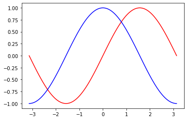

```
2π radians in degrees:  360.0
111 degrees in radians:  1.9373154697137058
The pythagorean triple 3-4-5 has a hypotenuse of:  5.0
Arcsine(1) =  1.5707963267948966
Arccosine(1) =  0.0
Arctangent(0) = 0.0
Arctangent2(x,y) = [ 0.78539816 -0.68103388]
```

```python
pi_array = np.linspace(-np.pi, np.pi, 100) #Very useful for plotting anything trigonometric

#Plot with x axis & y axis data
plt.plot(pi_array, np.sin(pi_array), 'r') # plotting sine
plt.plot(pi_array, np.cos(pi_array), 'b') # plotting cosine
#plt.plot(pi_array, np.tan(pi_array), 'g') # plotting tangent
plt.show() #Display the plots, I commented tan out so sine and cosine can be seen because tan dominates.

np.rad2deg(2*np.pi)# radians to degrees
np.deg2rad(111)# degrees to radians
np.hypot(3,4)# hypotenuse(a,b)
print("2π radians in degrees: ", np.rad2deg(2*np.pi))
print("111 degrees in radians: ", np.deg2rad(111))
print("The pythagorean triple 3-4-5 has a hypotenuse of: ", np.hypot(3,4))



'''Inverse trig functions'''
np.arcsin(1)
np.arccos(1)
np.arctan(0)
print("Arcsine(1) = ", np.arcsin(1))
print("Arccosine(1) = ", np.arccos(1))
print("Arctangent(0) =", np.arctan(0))

#Note about arctan vs arctan2:
#arctan is a 2-quadrant inverse function, arctan2 is a 4-quadrant inverse function.
y=[1,-1]
x=[1,1.234]
print("Arctangent2(x,y) =", np.arctan2(y,x))
```

# Matrices and Vectors

> Think about this in terms of set theory: A vector is a list of numbers and a matrix is a list of lists. In other words, a vector is a set and a matrix is a set of sets.

## Lists and Arrays

```python
import numpy as np
v1 = [1,2,3]
v2 = [4,5,6]

a1 = [[1,2,3],[4,5,6], [7,8,9]]
a2 = [[9,8,7],[6,5,4], [3,2,1]]

print("v1=",v1)
print("a1=",a1)

##Redefining them as numpy arrays
v1 =np.array([1,2,3])
v2 =np.array([4,5,6])

a1 = np.array([[1,2,3],[4,5,6], [7,8,9]])
a2 = np.array([[9,8,7],[6,5,4], [3,2,1]])

print("v1=",v1)
print("a1= \n",a1)
##If you add a new line it doesn't output so clunky.

v1 + v2 #Returns a vector
a1 + a2 #Returns a matrix
print("v1=",v1)
print("a1= \n",a1)
print("a1 + v1 = \n", a1+v1) #This adds v1 to each row in a1 with a polymorphic mapping

'''This is not the matrix multiplication you are used to,
it is element by element otherwise known as the Hadamard product'''
print("v1=", v1)
print("v2=", v2)
print("v1*v1=", v1*v1)
print("v2*v2=", v2*v2)
print("v1*v2=", v1*v2)
print("v2*v1=", v2*v1)
#If you look down the entries of each column you can see how it is being computed.
#Ordinary matrix multiplication is not that simple.

''' The Hadamard product of two 3x3 matrices is a breeze compared to standard matrix multiplication
1*3 = 3, 2*5 = 10, 3*6 = 18...etc.
Realistically, this is just another form of polymorphism.
 '''
v3 = np.array([[1,2,3],[4,5,6], [7,8,9]])
v4 = np.array([[3,5,6],[9,8,7], [1,5,9]])
v3*v4

'''It may be easier to see how the Hadamard product is computed by dividing matrices'''
v3 = np.array([[1,2,3],[4,5,6], [7,8,9]])
v3/v3 #1/1, 2/2, 3/3....9/9
```

```
v1= [1, 2, 3]
a1= [[1, 2, 3], [4, 5, 6], [7, 8, 9]]
v1= [1 2 3]
a1=
 [[1 2 3]
 [4 5 6]
 [7 8 9]]
v1= [1 2 3]
a1=
 [[1 2 3]
 [4 5 6]
 [7 8 9]]
a1 + v1 =
 [[ 2  4  6]
 [ 5  7  9]
 [ 8 10 12]]
v1= [1 2 3]
v2= [4 5 6]
v1*v1= [1 4 9]
v2*v2= [16 25 36]
v1*v2= [ 4 10 18]
v2*v1= [ 4 10 18]
```

```
array([[1., 1., 1.],
       [1., 1., 1.],
       [1., 1., 1.]])
```

## Slicing out Rows and Columns from a Matrix

```python
v3 = np.array([[1,2,3],[4,5,6], [7,8,9]])
row0 = v3[0]
row1 = v3[1]
row2 = v3[2]
print("v3 = \n", v3)
print("row0 = ", row0)
print("row1 = ", row1)
print("row2 = ", row2)
```

```
v3 =
 [[1 2 3]
 [4 5 6]
 [7 8 9]]
row0 =  [1 2 3]
row1 =  [4 5 6]
row2 =  [7 8 9]
```

## Column slicing

> Note how they appear to be returned as rows, just use a transpose if you ever need to flip a row to a column.

```python
v3 = np.array([[1,2,3],[4,5,6], [7,8,9]])
column0 = v3[:,0] #This is a tuple specifying column 0
column1 = v3[:,1] #This is a tuple specifying column 1
column2 = v3[:,2] #This is a tuple specifying column 2
print("v3 = \n", v3)
print("column0 = ", column0)
print("column1 = ", column1)
print("column2 = ", column2)
```

```
v3 =
 [[1 2 3]
 [4 5 6]
 [7 8 9]]
column0 =  [1 4 7]
column1 =  [2 5 8]
column2 =  [3 6 9]
```

```python
A = np.array([[1,2,3], [4,5,6],[7,8,9]])
#since the python indexes at 0 instead of 1 unlike normal linear algebra
#I'll show what a 3x3 looks like with the printing function
print("A is \n", A, "\n")
print("A[0,0] is", A[0,0])
print("A[0,1] is", A[0,1])
print("A[0,2] is", A[0,2])
print("A[1,0] is", A[1,0])
print("A[1,1] is", A[1,1])
print("A[1,2] is", A[1,2])
print("A[2,0] is", A[2,0])
print("A[2,1] is", A[2,1])
print("A[2,2] is", A[2,2])
#Again, it bares repeating that (2,2) would normally be 3,3 because all we did was shift the index by 1
```

```
A is
 [[1 2 3]
 [4 5 6]
 [7 8 9]]

A[0,0] is 1
A[0,1] is 2
A[0,2] is 3
A[1,0] is 4
A[1,1] is 5
A[1,2] is 6
A[2,0] is 7
A[2,1] is 8
A[2,2] is 9
```

## The Dot Product and Cross Product

```python
v1 =np.array([1,2,3])
v2 =np.array([4,5,6])
innerp=np.dot(v1, v2)
crossp1=np.cross(v1,v2)
crossp2=np.cross(v2,v1)
print("\n The inner product of v1*v2 is:",innerp, #Notice that this is indeed a proper inner product: 1*4 + 2*5+3*6 == 4+10+18=32
      "\n The cross product of v1 x v2 is:", crossp1, #Cross products indeed return a vector
      "\n The cross product of v2 x v1 is:", crossp2)
```

```
 The inner product of v1*v2 is: 32
 The cross product of v1 x v2 is: [-3  6 -3]
 The cross product of v2 x v1 is: [ 3 -6  3]
```

```python
''' If you have an array you can use the function numpy.tile()
to obtain a new array by repeating it a given number of times'''

from numpy import tile
a = [1,2,3,4]
b = tile(a,3) # This will tile "a" 3 times
print("a tiled 3 times:", b)

c = [[1,2],[3,4]]
d = tile(c,3) # Notice the resultant pattern is [c[0]c[0]c[0]] [c[1]c[1]c[1]]
print("c tiled 3 times: \n", d)

# Note that a and c are lists but b and d are arrays
```

```
a tiled 3 times: [1 2 3 4 1 2 3 4 1 2 3 4]
c tiled 3 times:
 [[1 2 1 2 1 2]
 [3 4 3 4 3 4]]
```

# Linear algebra functions

```python
a = np.array([[1,2,3], [4,5,6], [7,8,9]])
b = a.transpose() #Or b = a.T for short
b2 = np.trace(a)
b3 = np.linalg.det(a)
print("a = \n", a)
print("a.transpose = \n", b)
print("trace(a) =  ", b2)
print("det(a)=  ", b3) #It's zero, but numpy can't quite compute it for some reason.
```

```
a =
 [[1 2 3]
 [4 5 6]
 [7 8 9]]
a.transpose =
 [[1 4 7]
 [2 5 8]
 [3 6 9]]
trace(a) =   15
det(a)=   -9.51619735392994e-16
```

```python
a = np.array([[4,6,8], [9,10,12], [14,15,16]])
b = np.array([[1,2,3], [5,7,11], [13,17,19]])
np.vdot(a,b) #vector dot product
np.inner(a,b) #inner product
np.outer(b,a) #outer product
np.matmul(a,b) #normal matrix multiplication
np.matmul(b,a) #recall it is not commutative
np.linalg.matrix_power(a,3) #raising a to the power of 3, so a*a*a
np.linalg.eig(a) #Gets eigenvalues and right eigenvectors
np.linalg.eigvals(a) #Gets eigenvalues
np.linalg.eigvals(b) #Gets eigenvalues
np.linalg.norm(a) #Gets the norm
np.linalg.det(a) #Gets the determinant
np.linalg.inv(b) #Gets the inverse

a = np.array([2, 3])
b = np.array([3, 2])
# Returns T/F based on entry-by-entry comparison of magnitude for a and b
np.greater(a, b)
np.greater_equal(a, b)
np.less(a, b)
np.less_equal(a, b)
np.not_equal(a, b)
np.equal(a, b)
print("np.greater(a, b): ", np.greater(a, b))
print("np.greater_equal(a, b): ", np.greater_equal(a, b))
print("np.less(a, b): ", np.less(a, b))
print("np.less_equal(a, b): ", np.less_equal(a, b))
print("np.not_equal(a, b): ", np.not_equal(a, b))
print("np.equal(a, b): ", np.equal(a, b))
```

```
np.greater(a, b):  [False  True]
np.greater_equal(a, b):  [False  True]
np.less(a, b):  [ True False]
np.less_equal(a, b):  [ True False]
np.not_equal(a, b):  [ True  True]
np.equal(a, b):  [False False]
```

# Saving and loading

```python
a = np.array([[1, 2], [3, 4]])
# Save
np.save('randarray', a)
# Load
b = np.load('randarray.npy')
b

# Savetxt as a .csv file
np.savetxt('randcsv.csv', a)
# Loading said .csv file
c = np.loadtxt('randcsv.csv')
c
```

```
array([[1., 2.],
       [3., 4.]])
```

# Plotting

> Almost all of the plotting I have is in the plotly, matplotlib, and seaborn notebooks but I borrowed these from my work in computational physics

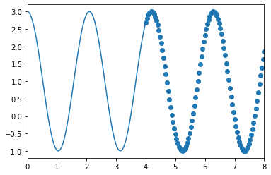

```python
x1 = np.linspace(0,4,101)
y1 = 1 + 2*np.cos(3*x1)
plt.xlim([0,8])
plt.plot(x1,y1)

x2 = np.linspace(4,8,101) #This merges with the first plot because it starts where the previous one ends
y2 = 1 + 2*np.cos(3*x2)
plt.scatter(x2,y2)
```

```python
np.meshgrid(np.linspace(0,5,6),
            np.linspace(5,10,6)) #Making a meshgrid from two linspaces
```

```
[array([[0., 1., 2., 3., 4., 5.],
        [0., 1., 2., 3., 4., 5.],
        [0., 1., 2., 3., 4., 5.],
        [0., 1., 2., 3., 4., 5.],
        [0., 1., 2., 3., 4., 5.],
        [0., 1., 2., 3., 4., 5.]]),
 array([[ 5.,  5.,  5.,  5.,  5.,  5.],
        [ 6.,  6.,  6.,  6.,  6.,  6.],
        [ 7.,  7.,  7.,  7.,  7.,  7.],
        [ 8.,  8.,  8.,  8.,  8.,  8.],
        [ 9.,  9.,  9.,  9.,  9.,  9.],
        [10., 10., 10., 10., 10., 10.]])]
```

```
<a list of 15 text.Text objects>
```

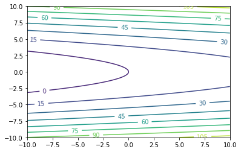

```python
x2, y2, = np.meshgrid(np.linspace(-10,10,201), np.linspace(-10,10,201)) #using the meshgrid as the domain
z2 = x2 + y2**2
contourplot= plt.contour(x2,y2,z2)
plt.clabel(contourplot, inline = 1, fontsize = 10)
```

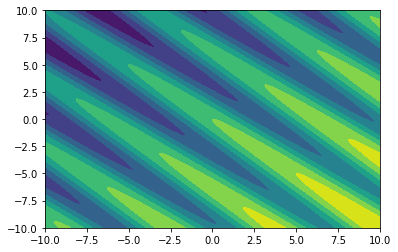

```python
x3, y3, = np.meshgrid(np.linspace(-10,10,201), np.linspace(-10,10,201))
z3 = np.cos(x3+y3) + 0.05*(x3-y3)

plt.contourf(x3,y3,z3) #contourf fills in the space between the lines
#this one looks better filled in compared to the one above which looks better with space
```

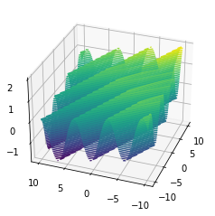

```python
plotproj = plt.axes(projection='3d')
plotproj.view_init(30,200)
plotproj.contour3D(x3,y3,z3, 50) #basic 3-D plot of sinusoidal functions
```

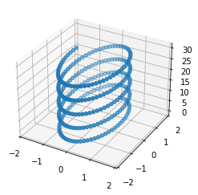

```python
plt3D = plt.axes(projection='3d')
z1 = np.linspace(0,30,301)
x1 = np.sin(z1)
y1 = 2*np.cos(z1)
plt.xlim([-2,2])
plt.ylim([-2,2])
plt3D.scatter3D(x1, y1, z1) #You basically make a coil by tracing a circle's arclength in 3d
```